# Capability Gap Radar — Methodology Note

How SHAP weights and Country RCA are computed for the Atlas radar panel

Author

Net Zero Industrial Policy Lab · Johns Hopkins SAIS

Published

May 18, 2026

## 1 What the Radar Shows

The **Capability Gap Radar** in the NZIPL Atlas displays two overlaid polygons for a given country × technology × year:

| Polygon | Colour | Meaning | Source |
| --- | --- | --- | --- |
| Amber (filled) | `#f59e0b` | **SHAP weight** — what the ML model says matters for this technology | `pc_features.csv` |
| Dashed (tech colour) | tech-specific | **Country RCA** — how specialised the country actually is | `pc_rca.parquet` |

A **dotted ring** marks RCA = 1 (the competitive threshold). Each axis = one of five product categories: Chemicals · Electronics · Industrial Materials · Machinery · Metals.

The gap between the two polygons on any axis signals a **capability gap** — the model predicts that category matters (high SHAP) but the country lacks specialisation (low RCA).

## 2 SHAP Weights — What the Model Needs

### 2.1 Source: `data/pc/pc_features.csv`

```
Columns: tech | hs_code | description | category | shap_mean_z
Rows:     one per (tech × HS product)
```

The `shap_mean_z` field is computed in the NZIPL Python ML pipeline:

1. A Random Forest is trained on a panel of (country × HS product × year) observations. The binary label is whether the country has RCA > 1 in that product (see ML Explainer §2).
2. SHAP values are computed for every observation — each value measures how much a given product feature “pushed” the prediction up or down.
3. Values are z-scored across all observations to make features with different scales comparable.
4. The **mean absolute z-score** across all (country, year) observations gives `shap_mean_z` for each (tech, hs_code). A higher value = more consistent predictive influence (ML Explainer §4).

> **Key point:** `shap_mean_z` is **not country-specific** — it is the model’s global assessment of how important each product is for predicting competitiveness in that technology, averaged equally across all 155 countries and all years in the training set.

### 2.2 Aggregation to category level

The Atlas aggregates product-level `shap_mean_z` to the five SHAP categories, then renormalises over HS-based categories only (see §6 for why macro features are excluded):

$$w_c^{\text{tech}} = \frac{\sum_{k \in \text{cat}_c} \text{shap\_mean\_z}_{k}^{\text{tech}}}{\sum_{c' \in \text{HS cats}} \sum_{k \in \text{cat}_{c'}} \text{shap\_mean\_z}_{k}^{\text{tech}}}$$

The amber polygon axis $c$ has length $r_c = R \cdot \min(2 w_c, 1)$, so a category capturing 50% of SHAP weight reaches the outer ring.

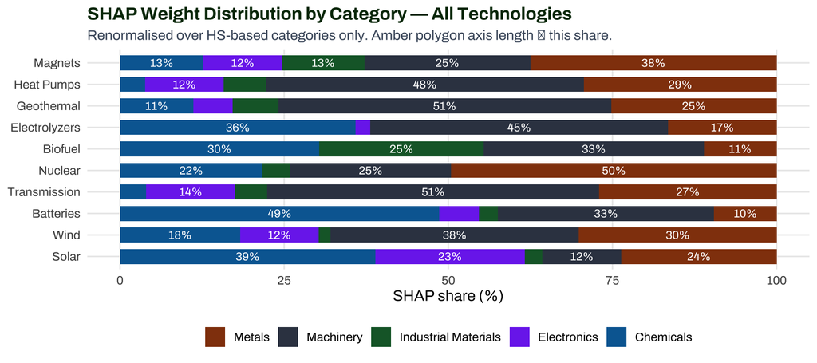

## 3 Country RCA — What the Country Has

### 3.1 Source: `data/pc/pc_rca.parquet`

```
Columns: iso3 | category | tech | year | rca | country | region
Rows:     one per (country × tech × category × year)
```

The category-level RCA for country $i$, technology $T$, category $c$, year $t$ is:

$$\text{RCA}_{i,c,T,t} = \frac{X_{i,c,T,t} / X_{i,\cdot,T,t}}{X_{\cdot,c,T,t} / X_{\cdot,\cdot,T,t}}$$

where $X$ are bilateral export values from `bilateral_ds` (KUSD). Numerator = country $i$’s share of its own tech exports that falls in category $c$; denominator = the world average share. RCA > 1 means the country is comparatively specialised in that category relative to all exporters.

> **Key point:** RCA is country-specific and year-specific. The dashed polygon varies across countries; the amber polygon does not.

### 3.2 RCA for India · Solar · 2023

India · Solar · 2023 — RCA by product category

| Category | RCA | Competitive |
| --- | --- | --- |
| Chemicals | 0.459 | No |
| Electronics | 0.189 | No |
| Industrial Materials | 0.226 | No |
| Machinery | 0.661 | No |
| Metals | 0.928 | No |

## 4 Combining Both: Classification Rules

Each axis is classified by comparing its SHAP weight $w_c$ and country RCA $r_c$:

| Condition | Label | Colour | Meaning |
| --- | --- | --- | --- |
| $w_c \geq 0.25$ and $r_c < 0.5$ | **CRIT GAP** | Red | Highly important; country is far below competitive threshold |
| $r_c < 0.5$ and $w_c \geq 0.10$ | **GAP** | Orange | Moderately important; country lacks specialisation |
| $r_c \geq 1.0$ | **STRENGTH** | Green | Country is competitive; model also values this |
| $r_c \geq 0.5$ | **BUILD** | Cyan | Country is approaching competitiveness |
| otherwise | **LOW PRIORITY** | Gray | Model places low weight on this category |

## 5 Worked Example: India · Solar (2023)

India · Solar · 2023 — Radar values (matches WP-4 Figure 4)

| Category | SHAP % | RCA | Classification | Axis length |
| --- | --- | --- | --- | --- |
| Chemicals | 38.9 | 0.46 | CRIT GAP | 78% of R |
| Electronics | 22.7 | 0.19 | GAP | 45% of R |
| Industrial Materials | 2.7 | 0.23 | LOW PRIORITY | 5% of R |
| Machinery | 12.0 | 0.66 | BUILD | 24% of R |
| Metals | 23.7 | 0.93 | BUILD | 47% of R |

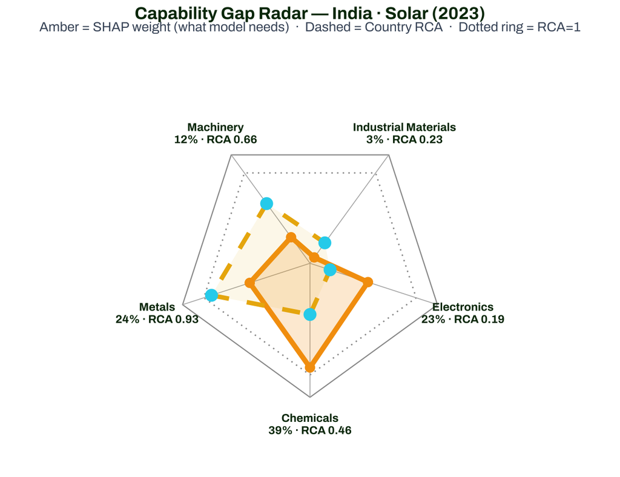

The figure reproduces WP-4 Figure 4 exactly. Chemicals is the critical gap: the model assigns ~39% of its predictive weight to chemical-sector products, but India’s RCA in that category is only 0.46. Metals and Machinery are building-up positions (RCA 0.66–0.93), while Electronics is a moderate gap.

## 6 What the Radar Does and Does Not Capture

### 6.1 Specificity: tech-specific vs country-specific vs country×tech-specific

The radar combines two signals with different scopes:

| Signal | Varies by | Current source | Country-specific? |
| --- | --- | --- | --- |
| SHAP weight (amber) | Tech only | `pc_features.csv` — global mean across 155 countries | ✗ |
| Country RCA (dashed) | Country × Tech × Year | `pc_rca.parquet` | ✓ |
| Country-specific SHAP | Country × Tech | Not yet stored — requires pipeline change | — |
| PC score | Country × Tech × Year | `pc_scores.parquet` | ✓ |

**What country-specific SHAP would add.** The Python pipeline computes a SHAP value for every individual `(country, year, hs_code)` observation before averaging. For India × Solar, the model may rely more heavily on Machinery features (where India has meaningful RCA = 0.66, giving the RF a real signal to use) and less on Chemicals (where RCA = 0.46 yields a near-zero signal). Restricting the average to India’s own observations would produce an amber polygon shaped by India’s actual position on the decision trees — potentially shifting the classification from CRIT GAP to BUILD on some axes.

**Note**

**Path to country-specific SHAP.** The developer can share the serialised model object (`joblib.dump(model, 'rf_solar.pkl')` in Python). We can then load it and call `shap.TreeExplainer(model).shap_values(X_india)` for any country’s feature matrix without retraining anything. Alternatively, a single additional `groupby(['iso3','tech','category'])` in the pipeline before the mean aggregation step would output the needed file directly.

### 6.2 Category definitions: HS chapters

The five SHAP categories are a property of the HS code, not of the technology. They follow standard HS chapter groupings and were verified to be perfectly consistent across techs — zero cases of the same HS code assigned to different categories for different technologies.

| SHAP Category | HS Chapters | Examples |
| --- | --- | --- |
| **Chemicals** | 28–39 | Inorganic/organic chemicals, plastics, polymers, paints, photographic materials |
| **Electronics** | 85 | Electrical machinery, semiconductors, instruments |
| **Machinery** | 84, 86–96 | Mechanical appliances, optical/measuring instruments, vehicles |
| **Metals** | 26, 71–83 | Ores, iron/steel, copper, aluminium, precious metals |
| **Industrial Materials** | 25, 27, 44, 68–70 | Minerals, petroleum, wood, ceramics, glass |
| **Other** | 1–24 | Agricultural commodities, food (mainly biofuel feedstocks) |

These two columns (`shap_category`, `shap_category_source`) have been added to `data/green_dict/green_dictionary.csv` — the master HS code reference file — for all 605 entries. 373 rows carry a `pc_features` source (directly confirmed by the ML model’s above-threshold SHAP values); the remaining 232 are `chapter_inferred`.

### 6.3 Number of products per category × technology

The table below shows how many distinct HS products the ML model assigned to each category for each technology in `pc_features.csv` (model-confirmed products only). Cells showing **1** identify categories where the entire SHAP weight rests on a single HS code.

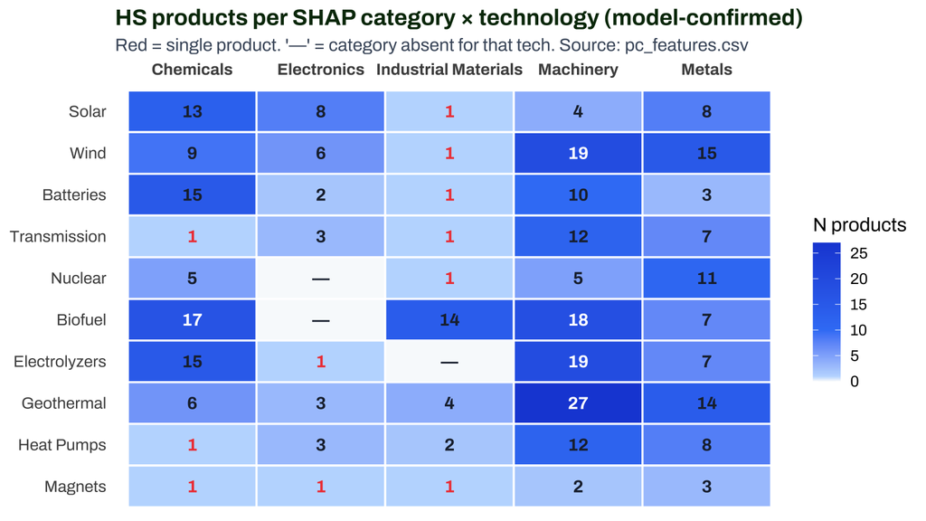

Number of HS products per category × tech in pc_features.csv (NA = category absent)

| Technology | Chemicals | Electronics | Industrial Materials | Machinery | Metals |
| --- | --- | --- | --- | --- | --- |
| Solar | 13 | 8 | 1 | 4 | 8 |
| Wind | 9 | 6 | 1 | 19 | 15 |
| Batteries | 15 | 2 | 1 | 10 | 3 |
| Transmission | 1 | 3 | 1 | 12 | 7 |
| Nuclear | 5 | NA | 1 | 5 | 11 |
| Biofuel | 17 | NA | 14 | 18 | 7 |
| Electrolyzers | 15 | 1 | NA | 19 | 7 |
| Geothermal | 6 | 3 | 4 | 27 | 14 |
| Heat Pumps | 1 | 3 | 2 | 12 | 8 |
| Magnets | 1 | 1 | 1 | 2 | 3 |

Single-product categories: the one HS code carrying 100% of that category’s SHAP weight

| Technology | Category | HS Code | Description | SHAP mean\|z\| |
| --- | --- | --- | --- | --- |
| Batteries | Industrial Materials | 251020 | Natural calcium phosphates, natural aluminium calcium phosphates and phosphatic chalk; ground | 0.504 |
| Electrolyzers | Electronics | 851430 | Furnaces and ovens; industrial or laboratory, other than those functioning by induction, dielectric loss or resistance heated | 0.538 |
| Heat Pumps | Chemicals | 281820 | Aluminium oxide; other than artificial corundum | 0.637 |
| Magnets | Chemicals | 283324 | Sulphates; of nickel | 0.593 |
| Magnets | Electronics | 851440 | Heating equipment; for the heat treatment of materials by induction or dielectric loss, industrial or laboratory, other than furnaces and ovens | 0.558 |
| Magnets | Industrial Materials | 680421 | Millstones, grindstones, grinding wheels and the like; of agglomerated synthetic or natural diamond | 0.585 |
| Nuclear | Industrial Materials | 250410 | Graphite; natural, in powder or in flakes | 0.519 |
| Solar | Industrial Materials | 250510 | Sands; natural, silica and quartz sands, whether or not coloured | 0.509 |
| Transmission | Chemicals | 281820 | Aluminium oxide; other than artificial corundum | 0.669 |
| Transmission | Industrial Materials | 270900 | Oils; petroleum oils and oils obtained from bituminous minerals, crude | 0.817 |
| Wind | Industrial Materials | 441520 | Wood; pallets, box pallets and other load boards; pallet collars | 0.501 |

### 6.4 Are the averages weighted?

`shap_mean_z` is an **unweighted mean** of absolute SHAP z-scores across all `(country, year)` observations. Specifically:

1. For each observation, SHAP produces a raw push value for every feature.
2. These are standardised (z-scored) **across all observations** for that feature — so a z-score of 2 for China × Solar in 2018 is on the same scale as a z-score of 2 for Fiji × Solar in 2018.
3. The absolute value is taken, then averaged equally across all observations.

**Consequences of equal weighting:**

- China ($100B in solar panels) counts the same as a small island economy in shaping `shap_mean_z`. The amber polygon reflects what matters for the *average country in the training set*, not for large exporters.
- Observations where the model is very confident get the same vote as uncertain predictions.
- If averaged instead by export volume, the Chemicals axis would likely shrink (large exporters have diversified chemistry) and Machinery would grow.

The country RCA axis is similarly unweighted in its construction — it is a ratio relative to world averages, not scaled by a country’s absolute export size.

## 7 Critical Limitation: Macro Features Excluded from the Radar

The model uses two types of features. For Solar, ordered by `shap_mean_z`:

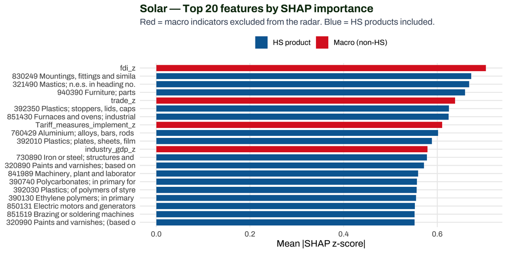

The six macro indicators — FDI inflows, trade openness, tariff measures, industry GDP share, total GDP, and manufacturing share — collectively account for **16% of total SHAP weight** for Solar, yet they are excluded from the radar because they do not map to a product category.

**Warning**

## 8 Relationship to the ML Pipeline

For fuller context see:

- **ML Pipeline Explainer** — end-to-end walkthrough of the Random Forest, SHAP computation, and PC scores for a non-technical audience.
- **ML Pipeline Review** — critical review of SHAP feature importance, RCA data coverage, and the SHAP ↔︎ trade correlation.

### 8.1 Data lineage

```
bilateral_ds (BACI trade flows)
  └─► 08_build_unilateral.R
        └─► pc_rca.parquet          ← Country RCA (dashed polygon)

NZIPL Python ML pipeline
  features: product-level RCA + 6 macro indicators
  target:   RCA > 1 per product (binary)
  train RF → compute SHAP per (country, year, hs_code)
  z-score → mean |z| across all countries → shap_mean_z
        └─► pc_features.csv         ← SHAP weights (amber polygon, HS only)

[not yet exported]
  groupby iso3 before averaging → per-country shap_mean_z
        └─► pc_features_by_country  ← country-specific amber polygon (future)
```

> **Note on country specificity.** Because the amber polygon is a global average, it will look the same for India and for Germany on any given tech. The dashed RCA polygon carries all the country-specific signal in the current design. Country-specific SHAP would allow the amber polygon to shift based on which categories the model actually uses when processing a specific country’s feature vector.